# R 기본함수를 이용한 데이터 가공과 시각화

2018-09-12

# 1 Gapminder data 로딩

- 국가별 통계자료를 모아놓은 Gapminder (http://www.gapminder.org/) 데이터의 축약본.
- 기대수명(life expectancy), GDP per capita(인당 GDP), population(인구) 데이터를 국가별, 대륙별로 제공.
- gapmind 패키지 설치로 데이터 로딩.

```r
#install.packages("gapminder")
library(gapminder)
head(gapminder)
```

```
## # A tibble: 6 x 6
##   country     continent  year lifeExp      pop gdpPercap
##   <fct>       <fct>     <int>   <dbl>    <int>     <dbl>
## 1 Afghanistan Asia       1952    28.8  8425333      779.
## 2 Afghanistan Asia       1957    30.3  9240934      821.
## 3 Afghanistan Asia       1962    32.0 10267083      853.
## 4 Afghanistan Asia       1967    34.0 11537966      836.
## 5 Afghanistan Asia       1972    36.1 13079460      740.
## 6 Afghanistan Asia       1977    38.4 14880372      786.
```

## 1.1 분석할 데이터의 자료구조 확인

```r
str(gapminder)
```

```
## Classes 'tbl_df', 'tbl' and 'data.frame':    1704 obs. of  6 variables:
##  $ country  : Factor w/ 142 levels "Afghanistan",..: 1 1 1 1 1 1 1 1 1 1 ...
##  $ continent: Factor w/ 5 levels "Africa","Americas",..: 3 3 3 3 3 3 3 3 3 3 ...
##  $ year     : int  1952 1957 1962 1967 1972 1977 1982 1987 1992 1997 ...
##  $ lifeExp  : num  28.8 30.3 32 34 36.1 ...
##  $ pop      : int  8425333 9240934 10267083 11537966 13079460 14880372 12881816 13867957 16317921 22227415 ...
##  $ gdpPercap: num  779 821 853 836 740 ...
```

6개의 변수(열)와 1704개의 관측치(행) 으로 구성된 데이터프레임

- country : factor with 142 levels (142개 국가)
- continent : factor with 5 levels (5개 대륙)
- year : ranges from 1952 to 2007 in increments of 5 years (1952년~2007년까지 5년 간격, int)
- lifeExp : life expectancy at birth, in years (해당연도에 태어난 사람의 기대수명, num)
- pop : population (인구수, int)
- gdpPercap : GDP per capita (US$, inflation-adjusted) (인당 GDP, num)

# 2 기술통계 분석

```r
summary(gapminder)  # 요약통계량
```

```
##         country        continent        year         lifeExp
##  Afghanistan:  12   Africa  :624   Min.   :1952   Min.   :23.60
##  Albania    :  12   Americas:300   1st Qu.:1966   1st Qu.:48.20
##  Algeria    :  12   Asia    :396   Median :1980   Median :60.71
##  Angola     :  12   Europe  :360   Mean   :1980   Mean   :59.47
##  Argentina  :  12   Oceania : 24   3rd Qu.:1993   3rd Qu.:70.85
##  Australia  :  12                  Max.   :2007   Max.   :82.60
##  (Other)    :1632
##       pop              gdpPercap
##  Min.   :6.001e+04   Min.   :   241.2
##  1st Qu.:2.794e+06   1st Qu.:  1202.1
##  Median :7.024e+06   Median :  3531.8
##  Mean   :2.960e+07   Mean   :  7215.3
##  3rd Qu.:1.959e+07   3rd Qu.:  9325.5
##  Max.   :1.319e+09   Max.   :113523.1
##
```

```r
mean(gapminder$lifeExp)  # 평균값
```

```
## [1] 59.47444
```

```r
median(gapminder$lifeExp)  # 중앙값
```

```
## [1] 60.7125
```

```r
sd(gapminder$lifeExp)  # 표준편차 standard deviation
```

```
## [1] 12.91711
```

```r
var(gapminder$lifeExp)  # 분산 variance
```

```
## [1] 166.8517
```

```r
min(gapminder$lifeExp)  # 최소값
```

```
## [1] 23.599
```

```r
max(gapminder$lifeExp)  # 최대값
```

```
## [1] 82.603
```

```r
quantile(gapminder$lifeExp)  # 사분위수
```

```
##      0%     25%     50%     75%    100%
## 23.5990 48.1980 60.7125 70.8455 82.6030
```

```r
fivenum(gapminder$lifeExp) # 최소값, 1사분위, 중위수, 3사분위, 최대값
```

```
## [1] 23.5990 48.1850 60.7125 70.8460 82.6030
```

```r
round(fivenum(gapminder$lifeExp), 1) # 소수점 자리수 지정 (반올림)
```

```
## [1] 23.6 48.2 60.7 70.8 82.6
```

```r
ceiling(fivenum(gapminder$lifeExp)) # 올림
```

```
## [1] 24 49 61 71 83
```

```r
abs(fivenum(gapminder$lifeExp)) # 절대값
```

```
## [1] 23.5990 48.1850 60.7125 70.8460 82.6030
```

## 2.1 Package ‘Hmisc’(Harrell Miscellaneous)

- Author : Frank E Harrell Jr
- Contains many functions useful for data analysis
  - high-level graphics, utility operations
  - functions for computing sample size and power
  - importing and annotating datasets
  - imputing missing values
  - advanced table making
  - variable clustering
  - character string manipulation
  - conversion of R objects to LaTeX and html code
  - recoding variables.

```r
library(Hmisc)
Hmisc::describe(gapminder)  # 변수별로 다양한 기술통계량을 한번에 구해줌
```

```
## gapminder
##
##  6  Variables      1704  Observations
## ---------------------------------------------------------------------------
## country
##        n  missing distinct
##     1704        0      142
##
## lowest : Afghanistan        Albania            Algeria            Angola             Argentina
## highest: Vietnam            West Bank and Gaza Yemen, Rep.        Zambia             Zimbabwe
## ---------------------------------------------------------------------------
## continent
##        n  missing distinct
##     1704        0        5
##
## Value        Africa Americas     Asia   Europe  Oceania
## Frequency       624      300      396      360       24
## Proportion    0.366    0.176    0.232    0.211    0.014
## ---------------------------------------------------------------------------
## year
##        n  missing distinct     Info     Mean      Gmd      .05      .10
##     1704        0       12    0.993     1980    19.87     1952     1957
##      .25      .50      .75      .90      .95
##     1966     1980     1993     2002     2007
##
## Value       1952  1957  1962  1967  1972  1977  1982  1987  1992  1997
## Frequency    142   142   142   142   142   142   142   142   142   142
## Proportion 0.083 0.083 0.083 0.083 0.083 0.083 0.083 0.083 0.083 0.083
##
## Value       2002  2007
## Frequency    142   142
## Proportion 0.083 0.083
## ---------------------------------------------------------------------------
## lifeExp
##        n  missing distinct     Info     Mean      Gmd      .05      .10
##     1704        0     1626        1    59.47    14.82    38.49    41.51
##      .25      .50      .75      .90      .95
##    48.20    60.71    70.85    75.10    77.44
##
## lowest : 23.599 28.801 30.000 30.015 30.331, highest: 81.701 81.757 82.000 82.208 82.603
## ---------------------------------------------------------------------------
## pop
##        n  missing distinct     Info     Mean      Gmd      .05      .10
##     1704        0     1704        1 29601212 46384459   475459   946367
##      .25      .50      .75      .90      .95
##  2793664  7023596 19585222 54801370 89822054
##
## lowest :      60011      61325      63149      65345      70787
## highest: 1110396331 1164970000 1230075000 1280400000 1318683096
## ---------------------------------------------------------------------------
## gdpPercap
##        n  missing distinct     Info     Mean      Gmd      .05      .10
##     1704        0     1704        1     7215     8573    548.0    687.7
##      .25      .50      .75      .90      .95
##   1202.1   3531.8   9325.5  19449.1  26608.3
##
## lowest :    241.1659    277.5519    298.8462    299.8503    312.1884
## highest:  80894.8833  95458.1118 108382.3529 109347.8670 113523.1329
## ---------------------------------------------------------------------------
```

# 3 데이터프레임에서 특정 조건에 맞는 데이터 추출

## 3.1 행과열 선택 : [ ] 연산자로 인덱스

```r
gapminder[gapminder$country == "Korea, Rep.", "pop"]
```

```
## # A tibble: 12 x 1
##         pop
##       <int>
##  1 20947571
##  2 22611552
##  3 26420307
##  4 30131000
##  5 33505000
##  6 36436000
##  7 39326000
##  8 41622000
##  9 43805450
## 10 46173816
## 11 47969150
## 12 49044790
```

```r
gapminder[gapminder$country == "Korea, Rep.", c("year", "pop")]
```

```
## # A tibble: 12 x 2
##     year      pop
##    <int>    <int>
##  1  1952 20947571
##  2  1957 22611552
##  3  1962 26420307
##  4  1967 30131000
##  5  1972 33505000
##  6  1977 36436000
##  7  1982 39326000
##  8  1987 41622000
##  9  1992 43805450
## 10  1997 46173816
## 11  2002 47969150
## 12  2007 49044790
```

## 3.2 열 선택 : [행,열] 중에 지정하지 않으면 모든 행 또는 열 선택

```r
# gapminder$country  # $ 연산자로 열(column) 인덱스
gapminder[, c("year", "pop", "gdpPercap")]  # 열 이름을 벡터화하여 선택
```

```
## # A tibble: 1,704 x 3
##     year      pop gdpPercap
##    <int>    <int>     <dbl>
##  1  1952  8425333      779.
##  2  1957  9240934      821.
##  3  1962 10267083      853.
##  4  1967 11537966      836.
##  5  1972 13079460      740.
##  6  1977 14880372      786.
##  7  1982 12881816      978.
##  8  1987 13867957      852.
##  9  1992 16317921      649.
## 10  1997 22227415      635.
## # ... with 1,694 more rows
```

```r
gapminder[, 1:3]  # 숫자 인덱스
```

```
## # A tibble: 1,704 x 3
##    country     continent  year
##    <fct>       <fct>     <int>
##  1 Afghanistan Asia       1952
##  2 Afghanistan Asia       1957
##  3 Afghanistan Asia       1962
##  4 Afghanistan Asia       1967
##  5 Afghanistan Asia       1972
##  6 Afghanistan Asia       1977
##  7 Afghanistan Asia       1982
##  8 Afghanistan Asia       1987
##  9 Afghanistan Asia       1992
## 10 Afghanistan Asia       1997
## # ... with 1,694 more rows
```

## 3.3 특정 조건을 갖는 행 선택 : " == " 연산자로 조건지정

```r
gapminder[gapminder$country == "Korea, Rep.", ]
```

```
## # A tibble: 12 x 6
##    country     continent  year lifeExp      pop gdpPercap
##    <fct>       <fct>     <int>   <dbl>    <int>     <dbl>
##  1 Korea, Rep. Asia       1952    47.5 20947571     1031.
##  2 Korea, Rep. Asia       1957    52.7 22611552     1488.
##  3 Korea, Rep. Asia       1962    55.3 26420307     1536.
##  4 Korea, Rep. Asia       1967    57.7 30131000     2029.
##  5 Korea, Rep. Asia       1972    62.6 33505000     3031.
##  6 Korea, Rep. Asia       1977    64.8 36436000     4657.
##  7 Korea, Rep. Asia       1982    67.1 39326000     5623.
##  8 Korea, Rep. Asia       1987    69.8 41622000     8533.
##  9 Korea, Rep. Asia       1992    72.2 43805450    12104.
## 10 Korea, Rep. Asia       1997    74.6 46173816    15994.
## 11 Korea, Rep. Asia       2002    77.0 47969150    19234.
## 12 Korea, Rep. Asia       2007    78.6 49044790    23348.
```

```r
gapminder[gapminder$lifeExp == 23.599, ]
```

```
## # A tibble: 1 x 6
##   country continent  year lifeExp     pop gdpPercap
##   <fct>   <fct>     <int>   <dbl>   <int>     <dbl>
## 1 Rwanda  Africa     1992    23.6 7290203      737.
```

```r
gapminder[gapminder$year == 2007, ]
```

```
## # A tibble: 142 x 6
##    country     continent  year lifeExp       pop gdpPercap
##    <fct>       <fct>     <int>   <dbl>     <int>     <dbl>
##  1 Afghanistan Asia       2007    43.8  31889923      975.
##  2 Albania     Europe     2007    76.4   3600523     5937.
##  3 Algeria     Africa     2007    72.3  33333216     6223.
##  4 Angola      Africa     2007    42.7  12420476     4797.
##  5 Argentina   Americas   2007    75.3  40301927    12779.
##  6 Australia   Oceania    2007    81.2  20434176    34435.
##  7 Austria     Europe     2007    79.8   8199783    36126.
##  8 Bahrain     Asia       2007    75.6    708573    29796.
##  9 Bangladesh  Asia       2007    64.1 150448339     1391.
## 10 Belgium     Europe     2007    79.4  10392226    33693.
## # ... with 132 more rows
```

```r
gapminder[gapminder$country == "Korea, Rep." & gapminder$year == 2007, ]  # Boolean AND operator
```

```
## # A tibble: 1 x 6
##   country     continent  year lifeExp      pop gdpPercap
##   <fct>       <fct>     <int>   <dbl>    <int>     <dbl>
## 1 Korea, Rep. Asia       2007    78.6 49044790    23348.
```

```r
gapminder[1:10, ]  # 숫자 인덱스
```

```
## # A tibble: 10 x 6
##    country     continent  year lifeExp      pop gdpPercap
##    <fct>       <fct>     <int>   <dbl>    <int>     <dbl>
##  1 Afghanistan Asia       1952    28.8  8425333      779.
##  2 Afghanistan Asia       1957    30.3  9240934      821.
##  3 Afghanistan Asia       1962    32.0 10267083      853.
##  4 Afghanistan Asia       1967    34.0 11537966      836.
##  5 Afghanistan Asia       1972    36.1 13079460      740.
##  6 Afghanistan Asia       1977    38.4 14880372      786.
##  7 Afghanistan Asia       1982    39.9 12881816      978.
##  8 Afghanistan Asia       1987    40.8 13867957      852.
##  9 Afghanistan Asia       1992    41.7 16317921      649.
## 10 Afghanistan Asia       1997    41.8 22227415      635.
```

## 3.4 정렬 순서 지정

```r
gapminder[order(gapminder$year, gapminder$country), ]  # 연도순, 국가순 정렬
```

```
## # A tibble: 1,704 x 6
##    country     continent  year lifeExp      pop gdpPercap
##    <fct>       <fct>     <int>   <dbl>    <int>     <dbl>
##  1 Afghanistan Asia       1952    28.8  8425333      779.
##  2 Albania     Europe     1952    55.2  1282697     1601.
##  3 Algeria     Africa     1952    43.1  9279525     2449.
##  4 Angola      Africa     1952    30.0  4232095     3521.
##  5 Argentina   Americas   1952    62.5 17876956     5911.
##  6 Australia   Oceania    1952    69.1  8691212    10040.
##  7 Austria     Europe     1952    66.8  6927772     6137.
##  8 Bahrain     Asia       1952    50.9   120447     9867.
##  9 Bangladesh  Asia       1952    37.5 46886859      684.
## 10 Belgium     Europe     1952    68    8730405     8343.
## # ... with 1,694 more rows
```

## 3.5 변수명 바꾸기

```r
names(gapminder) # 변수명 조회
```

```
## [1] "country"   "continent" "year"      "lifeExp"   "pop"       "gdpPercap"
```

```r
names(gapminder)[6] <- 'gdpPerCap' # 6번째 변수명 변경
```

# 4 연속형 데이터 분석 및 시각화 : 기대수명과 인당GDP 상관관계 분석

## 4.1 우리나라 데이터 추출

```r
#  우리나라 표기방식 확인 : 유일한 값 확인
unique(gapminder$country)  # 열 중복제거
```

```
##   [1] Afghanistan              Albania
##   [3] Algeria                  Angola
##   [5] Argentina                Australia
##   [7] Austria                  Bahrain
##   [9] Bangladesh               Belgium
##  [11] Benin                    Bolivia
##  [13] Bosnia and Herzegovina   Botswana
##  [15] Brazil                   Bulgaria
##  [17] Burkina Faso             Burundi
##  [19] Cambodia                 Cameroon
##  [21] Canada                   Central African Republic
##  [23] Chad                     Chile
##  [25] China                    Colombia
##  [27] Comoros                  Congo, Dem. Rep.
##  [29] Congo, Rep.              Costa Rica
```

[output cut: 57 more lines]

```r
kor <- gapminder[gapminder$country == "Korea, Rep.", ]
```

## 4.2 연도, 기대수명, 인당 GDP 속성 추출

```r
kor <- kor[, c(3, 4, 6)] # 3, 4, 6 행만 추출
names(kor) <- c("year", "life_exp", "gdp_cap") # 칼럼명 변경
str(kor)
```

```
## Classes 'tbl_df', 'tbl' and 'data.frame':    12 obs. of  3 variables:
##  $ year    : int  1952 1957 1962 1967 1972 1977 1982 1987 1992 1997 ...
##  $ life_exp: num  47.5 52.7 55.3 57.7 62.6 ...
##  $ gdp_cap : num  1031 1488 1536 2029 3031 ...
```

## 4.3 두 연속형 변수의 관계 시각화

두개의 연속형 변수의 시각화는 산점도(Scatterplot)을 이용할 수 있다.

### 4.3.1 Generic X-Y Plotting

내장패키지 graphics::plot은 기본 산점도 그래프를 그리는 함수이다.

- usage : plot(x, y = NULL, type = “p”, xlim = NULL, ylim = NULL, log = “”, main = NULL, sub = NULL, xlab = NULL, ylab = NULL, ann = par(“ann”), axes = TRUE, frame.plot = axes, panel.first = NULL, panel.last = NULL, asp = NA, …)
- parameter :
  - type = “p” : points, “l” : lines, “b” : points & lines, “c” : empty points joined by lines, “o” : overplotted points and lines, “s” and “S” : stair steps, “h” for histogram-like vertical lines, “n” : does not produce any points or lines.
  - xlim, ylim : 각각 x축과 y축의 범위
  - main, sub : 각각 메인타이틀과 서브타이틀
  - xlab, ylab : 각각 x축과 y축의 제목

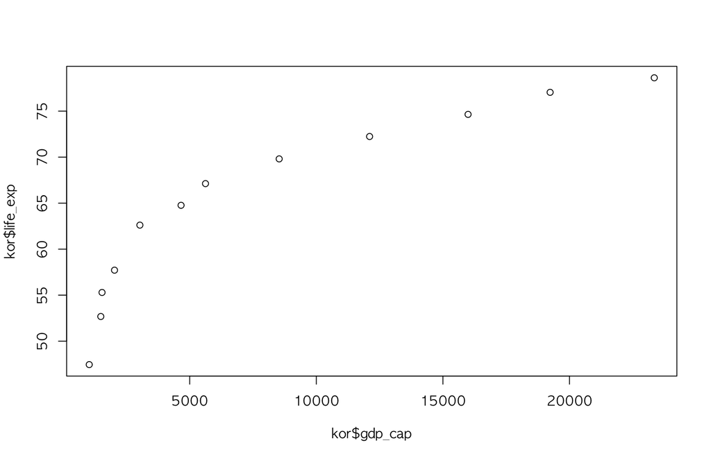

```r
plot(kor$gdp_cap, kor$life_exp, type = "p")
```

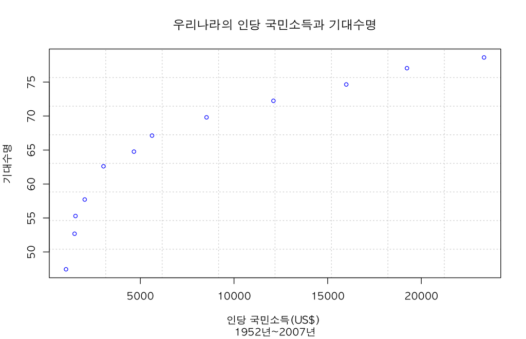

```r
plot(kor$gdp_cap, kor$life_exp,
     main = "우리나라의 인당 국민소득과 기대수명",
     sub = "1952년~2007년",
     xlab = "인당 국민소득(US$) ",
     ylab = "기대수명",
     panel.first = grid(8, 8),
     pch = 1, cex = 0.8, col = "blue")
```

### 4.3.2 Double Y Graph

연도별 인당 국민소득과 기대수명을 하나의 그래프에 표현

#### 4.3.2.1 latticeExtra 패키지의 doubleYScale() 함수를 이용

```r
#install.packages("latticeExtra")
library(latticeExtra)
```

#### 4.3.2.2 step 1. show original data

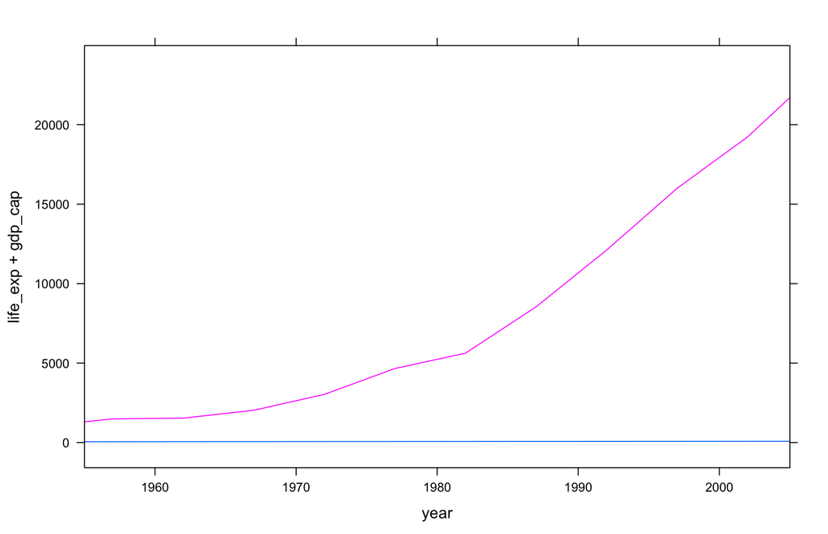

```r
xyplot(life_exp + gdp_cap ~ year, kor, xlim = c(1955, 2005), type = "l")
```

#### 4.3.2.3 step 2. construct separate plots for each series

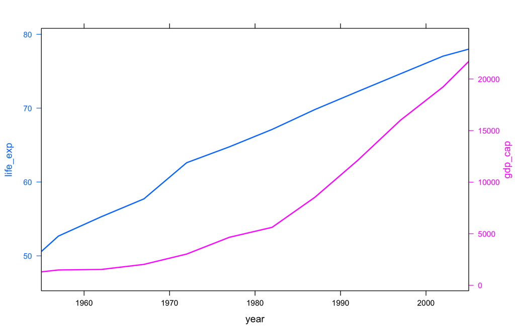

```r
obj1 <- xyplot(life_exp ~ year, kor, xlim = c(1955, 2005), type = "l", lwd=2)
obj2 <- xyplot(gdp_cap ~ year, kor, xlim = c(1955, 2005), type = "l", lwd=2)
doubleYScale(obj1, obj2, add.ylab2 = TRUE)
```

#### 4.3.2.4 re-plot with different styles

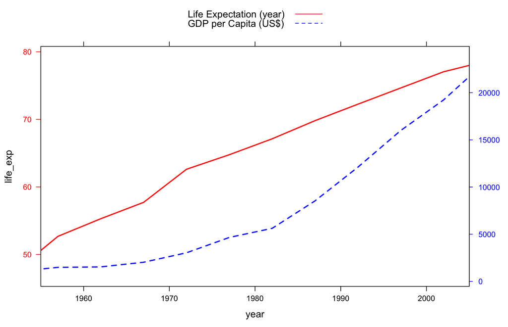

```r
update(doubleYScale(obj1, obj2,
    text = c("Life Expectation (year)", "GDP per Capita (US$)")),
    par.settings = simpleTheme(col = c('red','blue'), lty = 1:2))
```

### 4.3.3 doubleY graph 좀더 살펴보기

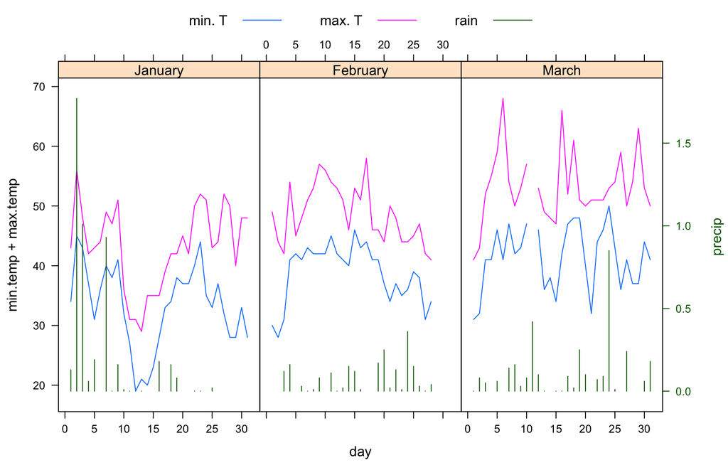

```r
## multi-panel
data(SeatacWeather)
temp <- xyplot(min.temp + max.temp ~ day | month,
               data = SeatacWeather, type = "l", layout = c(3, 1))
rain <- xyplot(precip ~ day | month, data = SeatacWeather, type = "h")

doubleYScale(temp, rain, style1 = 0, style2 = 3, add.ylab2 = TRUE,
   text = c("min. T", "max. T", "rain"), columns = 3)
```

### 4.3.4 ggplot2 패키지를 이용한 시각화

```r
# library(dplyr)
# library(ggplot2)
# gapminder %>% filter(year == 2007) %>%
#     ggplot(aes(gdpPercap, lifeExp)) +
#     geom_point() +
#     scale_x_log10() +
#     ggtitle("Gapminder data for 2007")
```

대륙과 인구수 변수도 나타내고 싶다.

```r
# library(ggplot2)
# gapminder %>% filter(year == 2007) %>%
#     ggplot(aes(gdpPercap, lifeExp)) +
#     geom_point(aes(size=pop, col=continent)) +
#     scale_x_log10() +
#     ggtitle("Gapminder data for 2007")
```

## 4.4 상관분석 (Correlation Analysis)

### 4.4.1 상관계수 (Correlation Coefficient)

- 상관계수는 두 변수 간의 선형적인 관계를 나타내는 측도
- 상관계수는 -1과 1사이의 값을 가지며, 1 또는 -1에 가까울수록 선형적인 관계가 강하며, 0에 가까울수록 그 관계가 약하다고 할 수 있다.
- 피어슨 상관계수(모수적), 스피어만 상관계수, 켄달의 타우(비모수적)
- cor() 함수로 상관분석을 수행한다.

```r
cor(kor$life_exp, kor$gdp_cap)
```

```
## [1] 0.9025423
```

### 4.4.2 상관계수에 대한 검정

```r
cor.test(kor$life_exp, kor$gdp_cap)
```

```
##
##  Pearson's product-moment correlation
##
## data:  kor$life_exp and kor$gdp_cap
## t = 6.6281, df = 10, p-value = 5.867e-05
## alternative hypothesis: true correlation is not equal to 0
## 95 percent confidence interval:
##  0.6817853 0.9726434
## sample estimates:
##       cor
## 0.9025423
```

## 4.5 회귀분석

설명변수(x) 를 이용하여 반응변수(y) 를 예측하기 위한 가장 간단하지만 유용한 모형은 선형회귀 모형 (linear regression model) 이다. 하나의 x 변수로 이루어진 모형을 단순회귀분석 모형 (simple regression model) 이라 한다.

- lm( ) 함수를 통해서 회귀 방정식과 R<sup>2</sup> 을 summary( ) 함수결과에서 확인할 수 있다.
- summary( ) 함수는 회귀를 해석하는데 필요한 모든 정보를 제공한다.

```r
lm1 <- lm(life_exp ~ gdp_cap, kor)
summary(lm1)
```

```
##
## Call:
## lm(formula = life_exp ~ gdp_cap, data = kor)
##
## Residuals:
##     Min      1Q  Median      3Q     Max
## -9.0608 -2.4260  0.2428  3.7943  5.1858
##
## Coefficients:
##              Estimate Std. Error t value Pr(>|t|)
## (Intercept) 5.530e+01  1.967e+00  28.113 7.53e-11 ***
## gdp_cap     1.181e-03  1.782e-04   6.628 5.87e-05 ***
## ---
## Signif. codes:  0 '***' 0.001 '**' 0.01 '*' 0.05 '.' 0.1 ' ' 1
##
## Residual standard error: 4.55 on 10 degrees of freedom
## Multiple R-squared:  0.8146, Adjusted R-squared:  0.796
## F-statistic: 43.93 on 1 and 10 DF,  p-value: 5.867e-05
```

### 4.5.1 회귀계수

- 절편(Intercept)과 기울기(slop)에 대한 추정값(Estimate), 표준편차(Std. Error), t값 (t value = Estimate/Std. Error), p값(Pr(>|t|)) 을 보여줌
- 적합된 모형은 다음과 같다.
  - lifeExp = 55.30 + 0.001181 * gdp_cap
- lifeExp 값에 대한 gdp_cap의 선형효과는 통계적으로 유의.
  - p-value: 5.867e-05, 귀무가설(Ho:beta = 0) reject

### 4.5.2 모형적합도 검정 (모형 전체의 설명력)

- 수정결정계수(Adjusted R-squared) : 0.796
- 반응변수의 총 변동 중 79.6% 가 모형으로 설명됨
- cf) 결정계수 (Multiple R-squared) 는 설명변수의 개수가 늘어날 때마다 항상 증가하기 때문에 적합한 성능척도가 아님. 이러한 문제점을 보완하기 위해서 설명변수 x 의 개수가 많아지면 패널티를 받도록 수정을 가한 값이 수정결정계수.

# 5 범주형 데이터 분석 : 대륙별 기대수명 분포

1. 상자수염그림(Boxplot) 을 사용하여 데이터를 시각화함으로써 집합간의 평균과 중앙값의 차이가 존재하는지, 이상치(outlier)는 존재하는지, 각 집단의 분산은 유사한지 등을 확인한다.
2. 설명변수가 범주형이고 반응변수가 수량형일 경우에는 lm( ) 함수로 ANOVA 선형모형을 적합하고 summary.lm( ) 함수로 결과를 분석한다.

## 5.1 Boxplot 으로 시각화

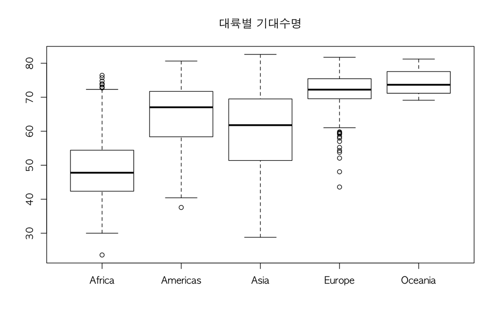

```r
boxplot(lifeExp~continent, gapminder, main="대륙별 기대수명")
```

## 5.2 분산분석(ANOVA) : 집단 별 차이가 통계적으로 의미가 있는지 검증

- 일원배치 분산분석 One-way ANOVA) : 독립된 세 집단 이상의 평균을 비교하고자 할 때 (평균의 차이가 의미 있는지 알아보고자 할 때) 사용하는 분석 방법

```r
summary(aov(lifeExp ~ continent, gapminder))
```

```
##               Df Sum Sq Mean Sq F value Pr(>F)
## continent      4 139343   34836   408.7 <2e-16 ***
## Residuals   1699 144805      85
## ---
## Signif. codes:  0 '***' 0.001 '**' 0.01 '*' 0.05 '.' 0.1 ' ' 1
```

- anova 함수에 lm(선형모델) 함수값을 전달하여 동일한 일원분산분석 수행할 수 있음.

```r
anova(lm(lifeExp ~ continent, gapminder))
```

```
## Analysis of Variance Table
##
## Response: lifeExp
##             Df Sum Sq Mean Sq F value    Pr(>F)
## continent    4 139343   34836  408.73 < 2.2e-16 ***
## Residuals 1699 144805      85
## ---
## Signif. codes:  0 '***' 0.001 '**' 0.01 '*' 0.05 '.' 0.1 ' ' 1
```

대륙 집단에 따른 평균 기대수명 차이는 통계적으로 유의함.

### 5.2.1 유럽 대륙 기대수명의 이상치(outlier) 값(value) 추출

`-1.5 * IQR` ~ `1.5 * IQR` 의 구간을 벗어나 있는 경우를 outlier 라 정의함.

```r
europe <- gapminder[gapminder$continent == "Europe", ]
boxplot.stats(europe$lifeExp)$out
```

```
##  [1] 55.230 59.280 53.820 58.450 59.600 59.164 59.820 57.996 43.585 48.079
## [11] 52.098 54.336 57.005 59.507
```

위 값에 해당되는 국가와 연도는 언제인가?

### 5.2.2 유럽의 기대수명 이상치(outlier) 데이터 추출

- outlier 여부를 TRUE/FALSE 로 반환하는 함수 정의
- `which( )`함수는 TRUE/FALSE 로 이루어진 vector를 인수로 받아서 TRUE 값을 가지는 index의 위치값을 반환

```r
is_outlier <- function(x) {
  return(x < quantile(x, 0.25) - 1.5 * IQR(x) | x > quantile(x, 0.75) + 1.5 * IQR(x))
}

which(is_outlier(europe$lifeExp))
```

```
##  [1]   1   2  37  38  49 193 241 265 337 338 339 340 341 342
```

### 5.2.3 행 인덱스를 추출하는 방법 2가지.

#### 5.2.3.1 위치값 인덱스 벡터를 대입하여 인덱스에 해당되는 행 추출

```r
europe[c(1, 2, 37, 38, 49, 193, 241, 265, 337, 338, 339, 340, 341, 342), ]
```

```
## # A tibble: 14 x 6
##    country                continent  year lifeExp      pop gdpPerCap
##    <fct>                  <fct>     <int>   <dbl>    <int>     <dbl>
##  1 Albania                Europe     1952    55.2  1282697     1601.
##  2 Albania                Europe     1957    59.3  1476505     1942.
##  3 Bosnia and Herzegovina Europe     1952    53.8  2791000      974.
##  4 Bosnia and Herzegovina Europe     1957    58.4  3076000     1354.
##  5 Bulgaria               Europe     1952    59.6  7274900     2444.
##  6 Montenegro             Europe     1952    59.2   413834     2648.
##  7 Portugal               Europe     1952    59.8  8526050     3068.
##  8 Serbia                 Europe     1952    58.0  6860147     3581.
##  9 Turkey                 Europe     1952    43.6 22235677     1969.
## 10 Turkey                 Europe     1957    48.1 25670939     2219.
## 11 Turkey                 Europe     1962    52.1 29788695     2323.
## 12 Turkey                 Europe     1967    54.3 33411317     2826.
## 13 Turkey                 Europe     1972    57.0 37492953     3451.
## 14 Turkey                 Europe     1977    59.5 42404033     4269.
```

#### 5.2.3.2 인덱스 벡터를 변수에 할당하여 행 인덱스

```r
index_vector <- is_outlier(europe$lifeExp)
europe[index_vector, ]
```

```
## # A tibble: 14 x 6
##    country                continent  year lifeExp      pop gdpPerCap
##    <fct>                  <fct>     <int>   <dbl>    <int>     <dbl>
##  1 Albania                Europe     1952    55.2  1282697     1601.
##  2 Albania                Europe     1957    59.3  1476505     1942.
##  3 Bosnia and Herzegovina Europe     1952    53.8  2791000      974.
##  4 Bosnia and Herzegovina Europe     1957    58.4  3076000     1354.
##  5 Bulgaria               Europe     1952    59.6  7274900     2444.
##  6 Montenegro             Europe     1952    59.2   413834     2648.
##  7 Portugal               Europe     1952    59.8  8526050     3068.
##  8 Serbia                 Europe     1952    58.0  6860147     3581.
##  9 Turkey                 Europe     1952    43.6 22235677     1969.
## 10 Turkey                 Europe     1957    48.1 25670939     2219.
## 11 Turkey                 Europe     1962    52.1 29788695     2323.
## 12 Turkey                 Europe     1967    54.3 33411317     2826.
## 13 Turkey                 Europe     1972    57.0 37492953     3451.
## 14 Turkey                 Europe     1977    59.5 42404033     4269.
```

## 5.3 연도별 이상치 빈도분석

### 5.3.1 도수분포표와 히스토그램

```r
europe_lifeExp_outlier <- europe[c(1, 2, 37, 38, 49, 193, 241, 265, 337, 338, 339, 340, 341, 342), ]
table(europe_lifeExp_outlier$year)
```

```
##
## 1952 1957 1962 1967 1972 1977
##    7    3    1    1    1    1
```

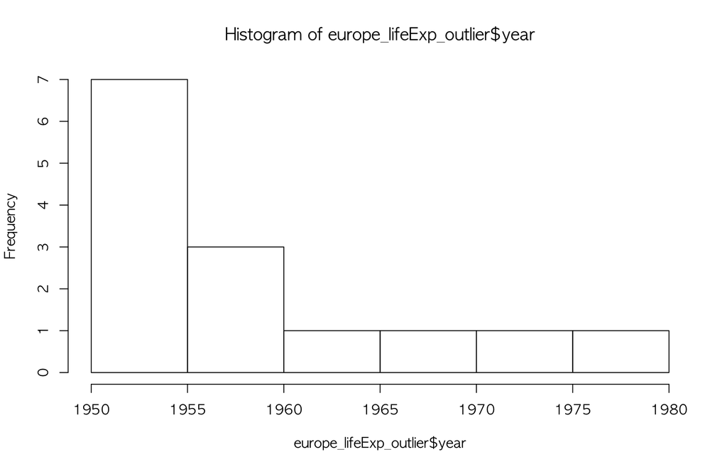

```r
hist(europe_lifeExp_outlier$year)
```

### 5.3.2 줄기-잎 그림

- 줄기-잎 그림(stem-and-leaf disply)은 연속형 자료를 시각적으로 나타내는 방법 가운데 하나로, stem() 함수를 사용한다.
- 자료의 큰 단위 값을 나무 줄기(stem)에, 작은 단위 값을 잎(leaf)에 배치하는 방법으로 자료를 시각화 하는 방법이다.

```r
#stem and leaf
stem(europe_lifeExp_outlier$year)
```

```
##
##   The decimal point is 1 digit(s) to the right of the |
##
##   195 | 2222222777
##   196 | 27
##   197 | 27
```

## 5.4 대륙별 평균 기대수명 비교

`aggregate( )` 함수를 이용하여 대륙별로 관측기간 평균 기대수명 산출

```r
aggregate(lifeExp ~ continent, gapminder, mean)
```

```
##   continent  lifeExp
## 1    Africa 48.86533
## 2  Americas 64.65874
## 3      Asia 60.06490
## 4    Europe 71.90369
## 5   Oceania 74.32621
```

```r
aggregate(lifeExp ~ continent, gapminder, median)
```

```
##   continent lifeExp
## 1    Africa 47.7920
## 2  Americas 67.0480
## 3      Asia 61.7915
## 4    Europe 72.2410
## 5   Oceania 73.6650
```

RMD 파일에서 R code 추출

```r
library(knitr)
purl("gapmind.Rmd", encoding = "UTF-8")
```

```
## [1] "gapmind.R"
```